# Buffering and Synergy Calls vs. Expected Additive Effect: Real Compared to Null

EYW

2026-09-23

```r
library(tidyverse)
library(data.table)
library(scales)
```

```r
knitr::opts_chunk$set(echo = TRUE)

source("../../functions/r_custom/plotting_fxns.R")
theme_set(theme_Publication())

filter_cutoff <- 0.1
real_interaction_dir <- "/data1/rudenska/EYW/git_projects/SIG13/analysis_outs/glmGamPoi/glmGamPoi_interaction"
null_dir <- "/data1/rudenska/EYW/git_projects/SIG13/analysis_outs/glmGamPoi/glmGamPoi_null"
plot_dir <- "../../analysis_outs/plots/interaction_scoring_null"

source_pal <- c(null = "#666666FF", real = "#1B9E77FF")
```

# Goal

`interaction_scoring_v3.R` reports that synergy is most common in genes whose expected additive effect is near zero, and buffering in genes where it is large. This notebook asks whether that pattern is stronger in the real data than in the empirical null built from the 9 non-targeting linker barcodes.

Each class is compared only with itself, real vs. null:

- **Buffering:** do real buffering calls come from genes with larger `|lfc_additive_expected|` than null buffering calls?
- **Synergy:** do real synergy calls come from genes with smaller `|lfc_additive_expected|` than null synergy calls?

The null shows where calls land when no biology drives them. The question is whether the real data departs from that in the predicted direction.

Quantities per gene x ligand pair, from the interaction GLM:

- `lfc_ligand1`, `lfc_ligand2`: single-ligand coefficients
- `lfc_interaction`: the `ligand1:ligand2` coefficient
- `lfc_additive_expected = lfc_ligand1 + lfc_ligand2`: the expected additive effect, which is the quantity under test
- `lfc_total_interaction_model = lfc_additive_expected + lfc_interaction`
- `interaction_score = lfc_interaction / lfc_total_interaction_model`: its sign sets the class (negative = buffering, positive = synergy)

## Two corrections

A naive real vs. null comparison is confounded in two ways.

**1. Percentile scale.** The null has no true effects, so all of its LFCs are smaller. Real calls would sit at higher raw LFCs for that reason alone. To remove this, `|lfc_additive_expected|` is converted to a percentile within each source’s own gene-tests, before any selection.

**2. Rate-matched selection.** At `adj_pval <= 0.1` the real data calls ~42x more of its gene-tests than the null does. The null’s few calls then come only from the extreme tail of its distribution, which pushes them toward percentile 1. To avoid this, both sources contribute the same fraction of gene-tests: the top hits by interaction p-value, with the fraction set to the null’s `adj_pval <= 0.1` rate.

# Load and derive quantities at matched filter_cutoff = 0.1

```r
build_table <- function(interaction_file, singles_file, source_label) {
  interactionTbl <- fread(interaction_file, select = c("name", "pval", "adj_pval", "lfc", "interaction")) %>%
    as_tibble() %>%
    rename(lfc_interaction = lfc, adj_pval_interaction = adj_pval, pval_interaction = pval)

  singlesTbl <- fread(singles_file, select = c("name", "lfc", "interaction", "single_ligand")) %>%
    as_tibble() %>%
    mutate(ligand_slot = if_else(grepl("_round1$", single_ligand), "lfc_ligand1", "lfc_ligand2")) %>%
    select(name, interaction, ligand_slot, lfc) %>%
    pivot_wider(names_from = ligand_slot, values_from = lfc)

  interactionTbl %>%
    inner_join(singlesTbl, by = c("name", "interaction")) %>%
    mutate(
      lfc_additive_expected = lfc_ligand1 + lfc_ligand2,
      abs_additive = abs(lfc_additive_expected),
      lfc_total_interaction_model = lfc_additive_expected + lfc_interaction,
      interaction_score = lfc_interaction / lfc_total_interaction_model,
      source = source_label
    )
}

realCombined <- build_table(
  file.path(real_interaction_dir, paste0("glmGamPoi_interaction_lfc_", filter_cutoff, "filter.csv")),
  file.path(real_interaction_dir, paste0("glmGamPoi_singles_lfc_", filter_cutoff, "filter.csv")),
  "real"
)

nullCombined <- build_table(
  file.path(null_dir, paste0("glmGamPoi_interaction_null_lfc_", filter_cutoff, "filter.csv")),
  file.path(null_dir, paste0("glmGamPoi_interaction_null_singles_lfc_", filter_cutoff, "filter.csv")),
  "null"
)
```

## Percentile of the expected additive effect

Computed within each source over all of its gene-tests, before any selection.

```r
allCombined <- bind_rows(realCombined, nullCombined) %>%
  group_by(source) %>%
  mutate(pct_abs_additive = percent_rank(abs_additive)) %>%
  ungroup()

allCombined %>% count(source, name = "n_gene_tests")
```

```
## # A tibble: 2 × 2
##   source n_gene_tests
##   <chr>         <int>
## 1 null         111062
## 2 real        4717971
```

The difference in effect size between sources, which the percentile scale removes:

```r
allCombined %>%
  group_by(source) %>%
  summarise(
    n = n(),
    median_abs_additive = median(abs_additive, na.rm = TRUE),
    q90_abs_additive = quantile(abs_additive, 0.9, na.rm = TRUE),
    median_abs_interaction = median(abs(lfc_interaction), na.rm = TRUE),
    q90_abs_interaction = quantile(abs(lfc_interaction), 0.9, na.rm = TRUE),
    .groups = "drop"
  ) %>%
  knitr::kable(digits = 4)
```

| source | n | median_abs_additive | q90_abs_additive | median_abs_interaction | q90_abs_interaction |
| --- | --- | --- | --- | --- | --- |
| null | 111062 | 0.0741 | 0.2188 | 0.0746 | 0.2269 |
| real | 4717971 | 0.1519 | 0.5805 | 0.0982 | 0.3003 |

## Hit rates and the matching fraction

```r
gatingRate <- allCombined %>%
  group_by(source) %>%
  summarise(
    n_gene_tests = n(),
    n_gated = sum(adj_pval_interaction <= 0.1, na.rm = TRUE),
    gated_rate = n_gated / n_gene_tests,
    .groups = "drop"
  )

knitr::kable(gatingRate, digits = 6)
```

| source | n_gene_tests | n_gated | gated_rate |
| --- | --- | --- | --- |
| null | 111062 | 67 | 0.000603 |
| real | 4717971 | 119275 | 0.025281 |

At `adj_pval <= 0.1`, the real data calls 2.53% of its gene-tests and the null calls 0.060%. The null’s rate is used as the matching fraction for both.

# Rate-matched selection

Each source keeps its top `match_rate` fraction of gene-tests by interaction p-value. Each kept gene-test is classed by the sign of `interaction_score`.

```r
match_rate <- gatingRate$gated_rate[gatingRate$source == "null"]
match_rate
```

```
## [1] 0.0006032666
```

```r
rateMatched <- allCombined %>%
  group_by(source) %>%
  mutate(pval_frac = percent_rank(pval_interaction)) %>%
  ungroup() %>%
  filter(pval_frac <= match_rate, is.finite(interaction_score)) %>%
  mutate(class_group = if_else(interaction_score < 0, "buffering", "synergy"))

rateMatched %>%
  count(source, class_group) %>%
  group_by(source) %>%
  mutate(frac = n / sum(n)) %>%
  ungroup() %>%
  knitr::kable(digits = 4)
```

| source | class_group | n | frac |
| --- | --- | --- | --- |
| null | buffering | 31 | 0.4627 |
| null | synergy | 36 | 0.5373 |
| real | buffering | 2605 | 0.9150 |
| real | synergy | 242 | 0.0850 |

This table is a result in its own right. It shows the buffering/synergy split among each source’s strongest interactions, with both sources selected at the same rate.

# Real vs. null within each class

```r
# oriented real - null: positive rank_biserial means real sits higher
source_summary <- function(df, value_col) {
  x <- df[[value_col]][df$source == "null"]
  y <- df[[value_col]][df$source == "real"]
  test <- suppressWarnings(wilcox.test(x, y))
  n1 <- length(x)
  n2 <- length(y)
  tibble(
    n_null = n1, n_real = n2,
    median_null = median(x, na.rm = TRUE), median_real = median(y, na.rm = TRUE),
    mean_null = mean(x, na.rm = TRUE), mean_real = mean(y, na.rm = TRUE),
    delta_mean = mean(y, na.rm = TRUE) - mean(x, na.rm = TRUE),
    p_value = test$p.value,
    # as.numeric() guards against 32-bit integer overflow in n1*n2
    rank_biserial = unname(1 - (2 * as.numeric(test$statistic)) / (as.numeric(n1) * as.numeric(n2)))
  )
}

# two-sample Kolmogorov-Smirnov on the same real-vs-null contrast.
# ks_D is the maximum vertical gap between the two ECDFs; ks_signed_D records
# where that gap sits, positive meaning real's ECDF runs above null's (real
# shifted toward LOWER percentiles), so it carries the direction that the
# two-sided D statistic discards.
ks_summary <- function(df, value_col) {
  x <- df[[value_col]][df$source == "null"]
  y <- df[[value_col]][df$source == "real"]
  test <- suppressWarnings(ks.test(y, x))
  grid <- sort(unique(c(x, y)))
  gap <- ecdf(y)(grid) - ecdf(x)(grid)
  tibble(
    ks_D = unname(test$statistic),
    ks_signed_D = gap[which.max(abs(gap))],
    ks_at_percentile = grid[which.max(abs(gap))],
    ks_p = test$p.value
  )
}

absAdditiveResults <- rateMatched %>%
  group_by(class_group) %>%
  group_modify(~ source_summary(.x, "pct_abs_additive")) %>%
  ungroup()

ksResults <- rateMatched %>%
  group_by(class_group) %>%
  group_modify(~ ks_summary(.x, "pct_abs_additive")) %>%
  ungroup()

absAdditiveResults %>%
  left_join(ksResults, by = "class_group") %>%
  knitr::kable(digits = 4)
```

| class_group | n_null | n_real | median_null | median_real | mean_null | mean_real | delta_mean | p_value | rank_biserial | ks_D | ks_signed_D | ks_at_percentile | ks_p |
| --- | --- | --- | --- | --- | --- | --- | --- | --- | --- | --- | --- | --- | --- |
| buffering | 31 | 2605 | 0.9995 | 0.9987 | 0.9926 | 0.9955 | 0.0029 | 0.4273 | -0.0828 | 0.1868 | 0.1868 | 0.9995 | 0.2356 |
| synergy | 36 | 242 | 0.9765 | 0.8496 | 0.9064 | 0.7690 | -0.1374 | 0.0000 | -0.5154 | 0.4369 | 0.4369 | 0.9758 | 0.0000 |

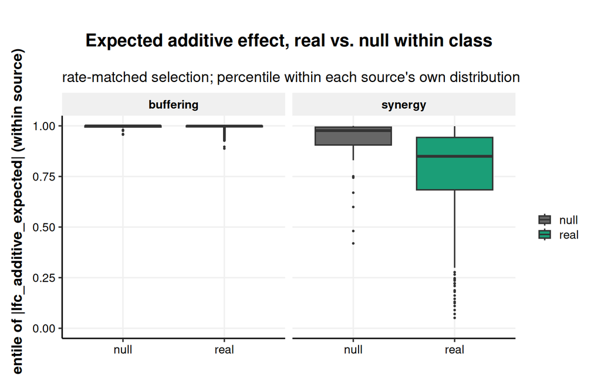

```r
ggplot(rateMatched, aes(x = source, y = pct_abs_additive, fill = source)) +
  geom_boxplot(outlier.size = 0.5) +
  scale_fill_manual(values = source_pal) +
  scale_y_continuous(limits = c(0, 1)) +
  facet_wrap(~class_group) +
  labs(x = NULL, y = "percentile of |lfc_additive_expected| (within source)", fill = NULL,
       title = "Expected additive effect, real vs. null within class",
       subtitle = "rate-matched selection; percentile within each source's own distribution") +
  theme(aspect.ratio = 1)
```

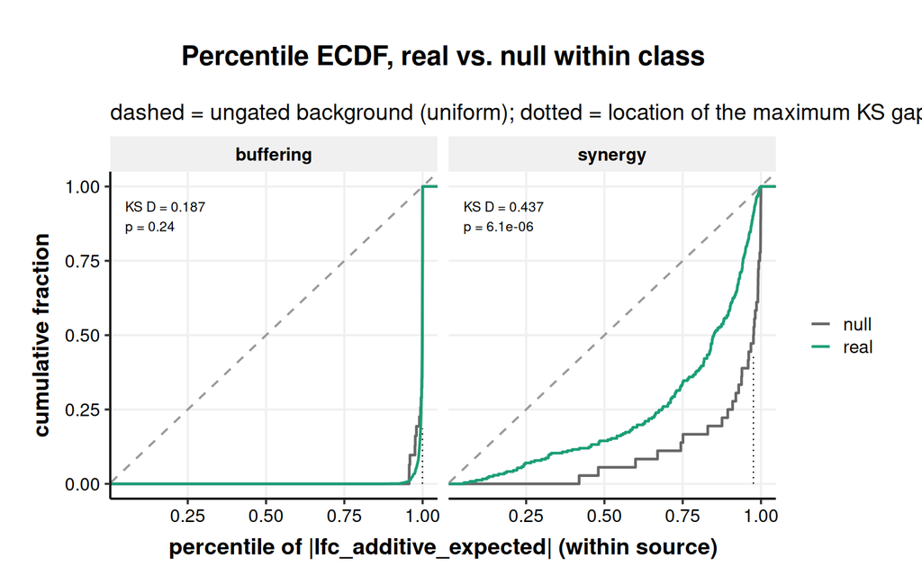

```r
ggsave(file.path(plot_dir, "05_rate_matched_abs_additive_boxplot.pdf"))
ksLabels <- ksResults %>%
  mutate(label = sprintf("KS D = %.3f\np = %s", ks_D, format.pval(ks_p, digits = 2)))

ggplot(rateMatched, aes(x = pct_abs_additive, color = source)) +
  stat_ecdf(linewidth = 0.8) +
  geom_abline(slope = 1, intercept = 0, linetype = "dashed", color = "grey60") +
  geom_segment(
    data = ksResults, inherit.aes = FALSE,
    aes(x = ks_at_percentile, xend = ks_at_percentile,
        y = 0, yend = abs(ks_signed_D)),
    colour = "black", linewidth = 0.4, linetype = "dotted"
  ) +
  geom_text(
    data = ksLabels, inherit.aes = FALSE,
    aes(x = 0.05, y = 0.95, label = label),
    hjust = 0, vjust = 1, size = 3, colour = "black"
  ) +
  scale_color_manual(values = source_pal) +
  facet_wrap(~class_group) +
  labs(x = "percentile of |lfc_additive_expected| (within source)",
       y = "cumulative fraction", color = NULL,
       title = "Percentile ECDF, real vs. null within class",
       subtitle = "dashed = ungated background (uniform); dotted = location of the maximum KS gap") +
  theme(aspect.ratio = 1)
```

```r
ggsave(file.path(plot_dir, "05_rate_matched_abs_additive_ecdf.pdf"))
```

The dashed diagonal is what an unselected set of gene-tests would give, since percentiles are uniform by construction. A curve below the diagonal means that class is enriched at large `|lfc_additive_expected|`. A curve above it means the class is enriched near zero.